# Invisibility Cloak — Independent Samples t-test

Emmanuel Fe Benito

2025-11-13

# Introduction

This report tests whether using an invisibility cloak affects the amount of mischief committed.  
We conduct an **independent-samples *t*-test** comparing mean Mischief scores for two groups: 1. Without cloak (`Cloak = 0`) 2. With cloak (`Cloak = 1`)

# 1. Setup

```r
library(tidyverse)
library(car)
```

```r
cloak <- read.csv("Invisibility Cloak.csv")

head(cloak)
```

|  | Participant | Cloak | Mischief |
| --- | --- | --- | --- |
| 1 | 1 | 0 | 3 |
| 2 | 2 | 0 | 1 |
| 3 | 3 | 0 | 5 |
| 4 | 4 | 0 | 4 |
| 5 | 5 | 0 | 6 |
| 6 | 6 | 0 | 4 |

```r
summary(cloak)
```

```
##   Participant        Cloak        Mischief
##  Min.   : 1.00   Min.   :0.0   Min.   :0.000
##  1st Qu.: 6.75   1st Qu.:0.0   1st Qu.:3.750
##  Median :12.50   Median :0.5   Median :5.000
##  Mean   :12.50   Mean   :0.5   Mean   :4.375
##  3rd Qu.:18.25   3rd Qu.:1.0   3rd Qu.:5.250
##  Max.   :24.00   Max.   :1.0   Max.   :8.000
```

# 2. Assumption Checks

## Assumption 1 — Dependent variable is continuous

`Mischief` is a numeric, continuous variable.

```r
cloak %>%
  group_by(Cloak) %>%
  summarise(
    n = n(),
    mean = mean(Mischief, na.rm = TRUE),
    sd = sd(Mischief, na.rm = TRUE)
  )
```

| Cloak | n | mean | sd |
| --- | --- | --- | --- |
| 0 | 12 | 3.75 | 1.912875 |
| 1 | 12 | 5.00 | 1.651446 |

## Assumption 2 — Independent variable has two groups

`Cloak` is categorical with two independent levels.

```r
unique(cloak$Cloak)
```

```
## [1] 0 1
```

```r
table(cloak$Cloak)
```

```
##
##  0  1
## 12 12
```

## Assumption 3 — Independence of observations

Each participant should belong to only one group.  
→ This is satisfied by design (not statistically testable from the data).

## Assumption 4 — Outliers

We identify outliers using the 1.5×IQR rule.

```r
find_outliers <- function(x){
  q1 <- quantile(x, 0.25)
  q3 <- quantile(x, 0.75)
  iqr <- q3 - q1
  lower <- q1 - 1.5*iqr
  upper <- q3 + 1.5*iqr
  x[x < lower | x > upper]
}

cloak %>%
  group_by(Cloak) %>%
  summarise(outliers = list(find_outliers(Mischief)))
```

| Cloak | outliers |
| --- | --- |
| 0 |  |
| 1 |  |

Visualize:

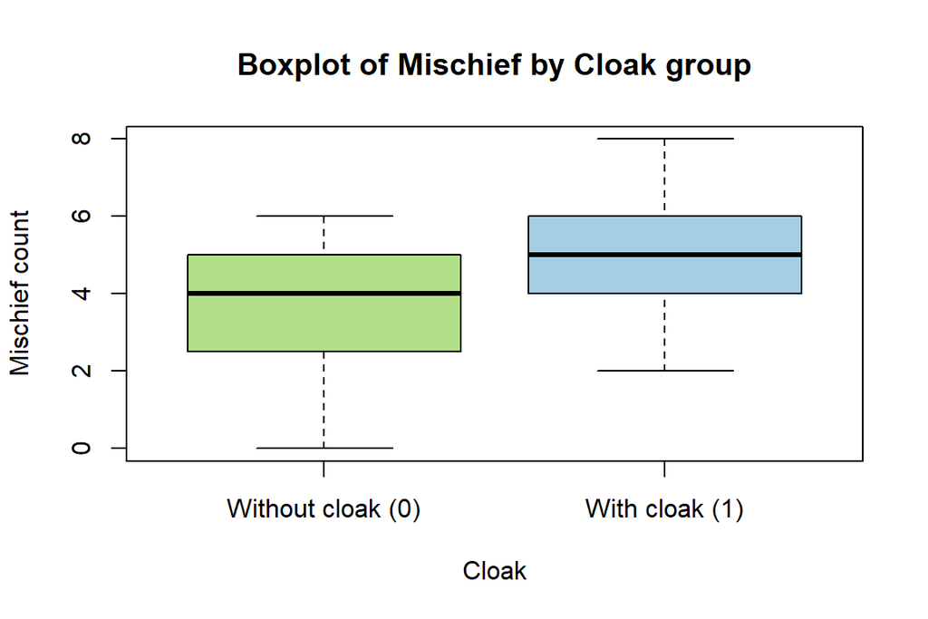

```r
boxplot(Mischief ~ Cloak, data=cloak,
        names=c("Without cloak (0)", "With cloak (1)"),
        main="Boxplot of Mischief by Cloak group",
        ylab="Mischief count", col=c("#b2df8a", "#a6cee3"))
```